# Forest structure variables

# Species rarefaction curves

We calculated rarefied species richness to compare forest plots across the globe, given that forest plots vary from 6 to 50 ha in size. Rarefaction was constructed based on sampling increment and each sample was a quadrat of 20x20 m quadrat size. We used the R packages BiodiversityR (Kindt & Coe, 2005) and vegan (Oksanen et al., 2020), following Gotelli & Collwel (2001) suggestions for rarefaction curve construction and used the species richness estimated at the smallest plot size.

```r
load(here("data", "rarefaction.curves.Rdata"))
#colors

pcols <- cols25(n=21)
names(pcols) <- unique(rare$fplot)
```

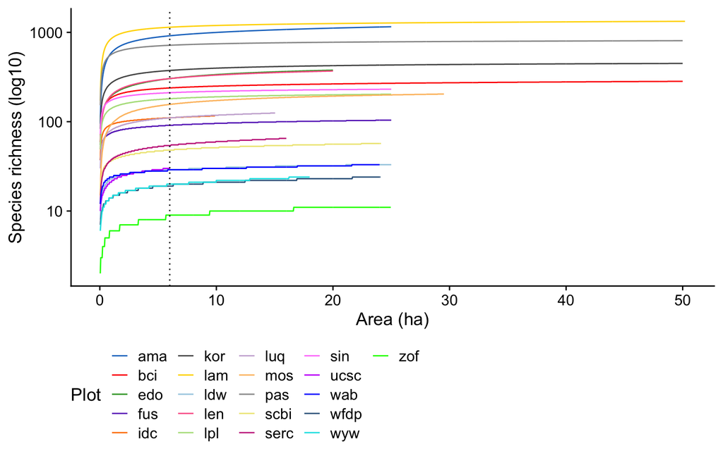

```r
prare <- ggplot(rare, aes(x=area,y=richness,col=fplot)) + geom_line() +
  geom_vline(xintercept=6, linetype="dotted") +
  scale_color_manual(values=pcols, name="Plot") +
  scale_y_log10()+
  xlab("Area (ha)") + ylab("Species richness (log10)") +
  theme(legend.position = "bottom")
prare
```

```r
png(here("figures", "FIG_S5.1_rarefaction_curves.png"), height = 700, width=800, res=150)
prare
dev.off()
```

# Forest structure

Contrasting forest strucutre and other variable across plots:

- Species richness
  - Rarefied species richness (6ha)
  - Total raw number of specie
  - Mean richness at 50x50m quadrat size
  - Coefficient of Variation (CV) of richness at 50x50m quadrat size
- Tree density
  - Total number of trees
  - Mean tree density at 50x50m quadrat size
  - Coefficient of Variation (CV) of tree density at 50x50m quadrat size
- Latitude
- Biogeographic realm

```r
load(here("data", "plots_structure.Rdata"))
```

Taking the log of richness and number of trees

```r
struc <- plots.structure %>% mutate_at(vars("n.species", "richness.rarefaction",
                                         "rich.mean50",
                                         "ntrees.total", "ntrees.mean50"), log) %>%
  as.data.frame()
rownames(struc) <- struc$fplot
```

PCA of variables

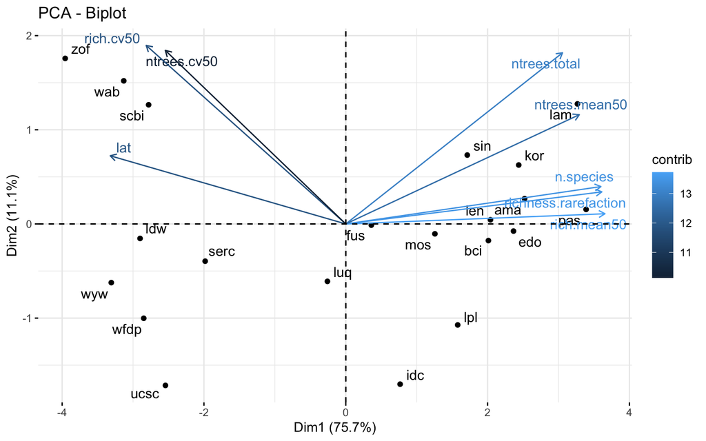

```r
pca.var <- PCA(struc[,c(2, 5:11)], graph=F)
fviz_pca(pca.var, repel=T,col.var="contrib")
```

```r
png(here("figures", "FIG_S5.2_pca_forestvariables.png"), height = 700, width=1000, res=150)
fviz_pca(pca.var, repel=T,col.var="contrib")
dev.off()
```

# References

Gotelli, N.J. & Colwell, R.K. (2001) Quantifying biodiversity: procedures and pitfalls in the measurement and comparison of species richness. Ecology Letters, 4, 379–391.

Kindt, R. & Coe, R. (2005) Tree diversity analysis: a manual and software for common statistical methods for ecological and biodiversity studies, World Agrofirestry Centre, Nairobi, Kenya.

Oksanen, J., Blanchet, F.G., Friendly, M., Kindt, R., Legendre, P., McGlinn, D., Minchin, P.R., O’Hara, R.B., Simpson, G.L., Solymos, P., Stevens, M.H.H., Szoecs, E. & Wagner, H. (2020) vegan: Community Ecology Package.